# Census Analysis (Appingway)

## Questions

1. Create a geographic map of states with low literacy rates.
2. Find out most similar districts in Bihar and Tamil Nadu. Similarity can be based on any of the columns from the data.
3. How does the mobile penetration vary in regions (districts or states) with high or low agricultural workers?

First, lets import all the necessary libraries

```python
import pandas as pd
from mpl_toolkits.basemap import Basemap,cm
import matplotlib.pyplot as plt
import numpy as np
import seaborn as sns
```

Loading the given data.

```python
df = pd.read_csv('india-districts-census-2011.csv')
```

```python
df.head()
```

|  | District code | State name | District name | Population | Male | Female | Literate | Male_Literate | Female_Literate | SC | ... | Power_Parity_Rs_90000_150000 | Power_Parity_Rs_45000_150000 | Power_Parity_Rs_150000_240000 | Power_Parity_Rs_240000_330000 | Power_Parity_Rs_150000_330000 | Power_Parity_Rs_330000_425000 | Power_Parity_Rs_425000_545000 | Power_Parity_Rs_330000_545000 | Power_Parity_Above_Rs_545000 | Total_Power_Parity |
| --- | --- | --- | --- | --- | --- | --- | --- | --- | --- | --- | --- | --- | --- | --- | --- | --- | --- | --- | --- | --- | --- |
| 0 | 1 | JAMMU & KASHMIR | Kupwara | 870354 | 474190 | 396164 | 439654 | 282823 | 156831 | 1048 | ... | 94 | 588 | 71 | 101 | 172 | 74 | 10 | 84 | 15 | 1119 |
| 1 | 2 | JAMMU & KASHMIR | Badgam | 753745 | 398041 | 355704 | 335649 | 207741 | 127908 | 368 | ... | 126 | 562 | 72 | 89 | 161 | 96 | 28 | 124 | 18 | 1066 |
| 2 | 3 | JAMMU & KASHMIR | Leh(Ladakh) | 133487 | 78971 | 54516 | 93770 | 62834 | 30936 | 488 | ... | 46 | 122 | 15 | 22 | 37 | 20 | 14 | 34 | 17 | 242 |
| 3 | 4 | JAMMU & KASHMIR | Kargil | 140802 | 77785 | 63017 | 86236 | 56301 | 29935 | 18 | ... | 27 | 114 | 12 | 18 | 30 | 19 | 3 | 22 | 7 | 214 |
| 4 | 5 | JAMMU & KASHMIR | Punch | 476835 | 251899 | 224936 | 261724 | 163333 | 98391 | 556 | ... | 78 | 346 | 35 | 50 | 85 | 59 | 8 | 67 | 12 | 629 |

5 rows × 118 columns

```python
df.info()
```

```
<class 'pandas.core.frame.DataFrame'>
RangeIndex: 640 entries, 0 to 639
Columns: 118 entries, District code to Total_Power_Parity
dtypes: int64(116), object(2)
memory usage: 590.1+ KB
```

Making new dataframes based on what features we need to analyse. Let us make the dataframe for literacy rate seperately as follows:

```python
df1 = df.iloc[:,0:4]
df2 = df.iloc[:,6]
literacy_data = pd.concat([df1, df2], axis=1) # concatenation of the two dataframes
literacy_data['Literacy Rate'] = (literacy_data['Literate']/literacy_data['Population'])*100
literacy_data.head()
```

|  | District code | State name | District name | Population | Literate | Literacy Rate |
| --- | --- | --- | --- | --- | --- | --- |
| 0 | 1 | JAMMU & KASHMIR | Kupwara | 870354 | 439654 | 50.514388 |
| 1 | 2 | JAMMU & KASHMIR | Badgam | 753745 | 335649 | 44.530843 |
| 2 | 3 | JAMMU & KASHMIR | Leh(Ladakh) | 133487 | 93770 | 70.246541 |
| 3 | 4 | JAMMU & KASHMIR | Kargil | 140802 | 86236 | 61.246289 |
| 4 | 5 | JAMMU & KASHMIR | Punch | 476835 | 261724 | 54.887749 |

As we will need the data of Bihar state and Tamil Nadu state, we make seperate datasets for those two too.

```python
Bihar = df.loc[df['State name'] == 'BIHAR']
TN = df.loc[df['State name'] == 'TAMIL NADU']
BTN = pd.concat([Bihar.iloc[:,1:], TN.iloc[:,1:]], axis = 0)
BTN.head()
```

|  | State name | District name | Population | Male | Female | Literate | Male_Literate | Female_Literate | SC | Male_SC | ... | Power_Parity_Rs_90000_150000 | Power_Parity_Rs_45000_150000 | Power_Parity_Rs_150000_240000 | Power_Parity_Rs_240000_330000 | Power_Parity_Rs_150000_330000 | Power_Parity_Rs_330000_425000 | Power_Parity_Rs_425000_545000 | Power_Parity_Rs_330000_545000 | Power_Parity_Above_Rs_545000 | Total_Power_Parity |
| --- | --- | --- | --- | --- | --- | --- | --- | --- | --- | --- | --- | --- | --- | --- | --- | --- | --- | --- | --- | --- | --- |
| 202 | BIHAR | Pashchim Champaran | 3935042 | 2061110 | 1873932 | 1759481 | 1091226 | 668255 | 553944 | 289191 | ... | 621 | 1968 | 138 | 21 | 159 | 30 | 49 | 79 | 40 | 3181 |
| 203 | BIHAR | Purba Champaran | 5099371 | 2681209 | 2418162 | 2276957 | 1407603 | 869354 | 649726 | 340363 | ... | 797 | 2551 | 223 | 18 | 241 | 25 | 40 | 65 | 47 | 4098 |
| 204 | BIHAR | Sheohar | 656246 | 346673 | 309573 | 283698 | 171645 | 112053 | 96655 | 51089 | ... | 90 | 301 | 4 | 1 | 5 | 2 | 3 | 5 | 4 | 489 |
| 205 | BIHAR | Sitamarhi | 3423574 | 1803252 | 1620322 | 1436794 | 885188 | 551606 | 405714 | 213624 | ... | 520 | 1670 | 69 | 10 | 79 | 14 | 22 | 36 | 29 | 2679 |
| 206 | BIHAR | Madhubani | 4487379 | 2329313 | 2158066 | 2155338 | 1340085 | 815253 | 587158 | 303389 | ... | 668 | 2203 | 165 | 7 | 172 | 10 | 17 | 27 | 26 | 3520 |

5 rows × 117 columns

BTN dataframe thus now contains both Bihar and TN census data.

```python
BTN.info()
```

```
<class 'pandas.core.frame.DataFrame'>
Int64Index: 70 entries, 202 to 632
Columns: 117 entries, State name to Total_Power_Parity
dtypes: int64(115), object(2)
memory usage: 64.5+ KB
```

Let us arbitrarily draw a correlation heatmap. Afer this, I will start analyising the questions given in the appingway test.

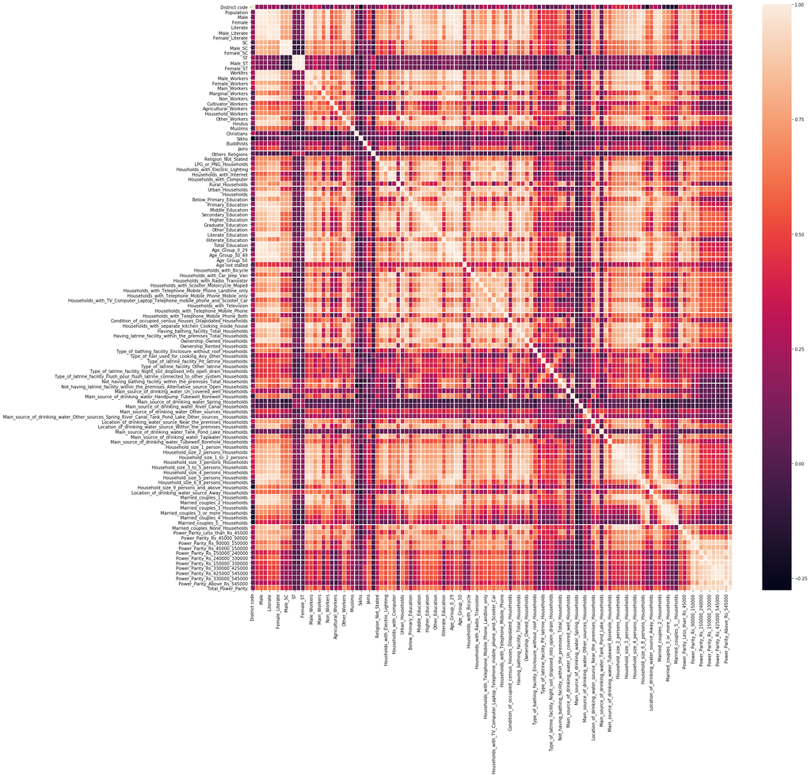

```python
f,ax = plt.subplots(figsize=(25, 25))
sns.heatmap(df.corr(), linewidths=.2,ax=ax)
```

## Geographical plot of literacy rate

To analyse geographically, I downloaded the lat/long JSON data all the cities in India from the github link: https://raw.githubusercontent.com/nshntarora/Indian-Cities-JSON/master/a-detailed-version.json

I am now extracting the lat long info from this JSON and matching it with the census data that I am given with.

```python
import json
citiesfile = open('Cities.txt', 'r')
cities = json.load(citiesfile)
lat, long, literacy_rate = [],[],[]
for rows in df.values:
    city = rows[2].lower() # To match the key style of the JSON data
    if city in cities:
        lat.append(cities[city]['latitude'])
        long.append(cities[city]['longitude'])
        literacy_rate.append((literacy_data['Literate'][rows[0]]/literacy_data['Population'][rows[0]])*100)
```

### Basemap plot

Im using basemap to plot the data on top of the map of india. i found the coordinates of the frame of India on Miller Projection online.

Using seaborn for the color scatter.

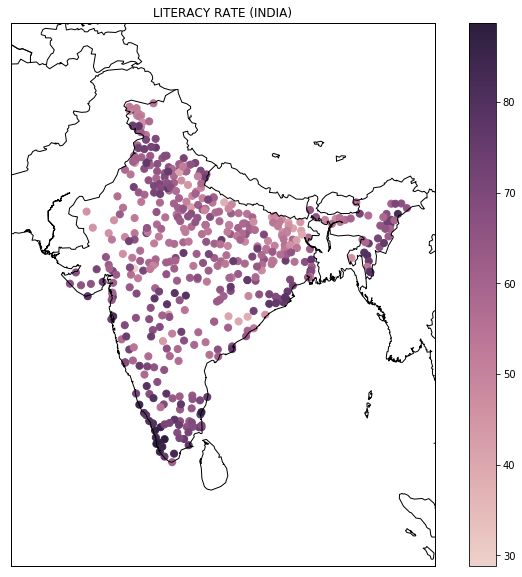

```python
df = pd.read_csv('india-districts-census-2011.csv')
f, ax = plt.subplots(figsize=(12,10))
m = Basemap(projection='mill',llcrnrlat=0,urcrnrlat=40,
            llcrnrlon=65,urcrnrlon=98,resolution='l')
m.drawcountries(linewidth=1.0)
m.drawstates()
m.drawcoastlines(linewidth=1.0)
m.drawmapboundary()
#m.fillcontinents(color='coral',lake_color='aqua')
plt.title('LITERACY RATE (INDIA)')
literacy_rate = list(map(str,literacy_rate))
X,Y=[],[]
for i in range(len(long)):
    x, y = m(float(long[i]), float(lat[i])) # compute map proj coordinates.
    X.append(x)
    Y.append(y)
cmap = sns.cubehelix_palette(as_cmap=True)
lr = list(map(str,literacy_rate))
points = ax.scatter(X,Y, c=lr, s=50, cmap=cmap)
f.colorbar(points)
plt.show()
```

```python
atts = df.iloc[:,3:].keys()
```

Atts variable will store all the names of the fields for labelling x axis further in the analysis.

## Finding similiar districts between Bihar and Tamil Nadu

Taking mean error of every field with the other field and storing the districts with their error in a seperate list.

Lower the error, more similarity there is between the districts. But first, let us plot all the districts of bihar and tn to see how the census data looks like.

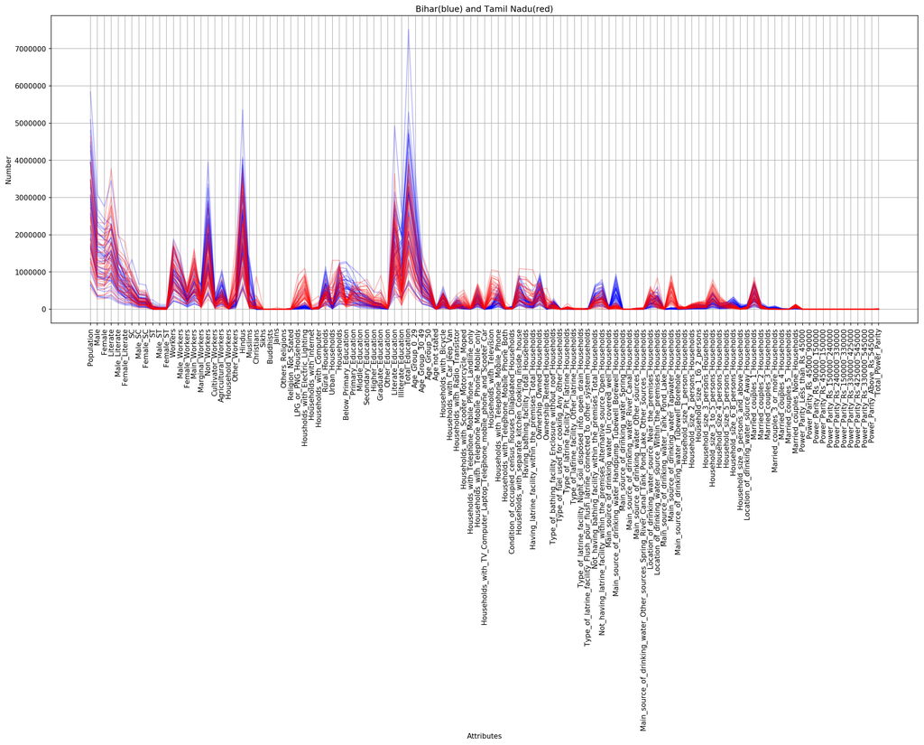

```python
x = np.arange(0,115)
plt.figure(1,figsize=(22,8), dpi = 150)
for y in BTN.values:
    if y[0] == 'BIHAR':
        plt.plot(x,y[2:], alpha=0.25, color = 'blue')
    else:
        plt.plot(x,y[2:], alpha=0.25, color = 'red')
plt.title('Bihar(blue) and Tamil Nadu(red)')
plt.xlabel('Attributes')
plt.ylabel('Number')
plt.grid()
plt.xticks(x,atts, rotation=90)
plt.show()
```

Now lets find the districts that are most similar.

```python
district_errors = []
bi = Bihar.values
tn = TN.values
for b in bi:
    for t in tn:
        error = b[3:]-t[3:]
        abs_mean_err = abs(np.mean(error))
        district_errors.append([abs_mean_err,b[2],t[2]])
district_errors.sort()
print('TEN MOST SIMILAR DISTRICTS WITH ERROR')
district_errors[0:10]
```

```
TEN MOST SIMILAR DISTRICTS WITH ERROR
```

```
[[24.678260869565218, 'Jamui', 'Dharmapuri'],
 [287.83478260869566, 'Araria', 'Thanjavur'],
 [564.9304347826087, 'Araria', 'Erode'],
 [645.3217391304348, 'Nawada', 'Kanniyakumari'],
 [1023.1739130434783, 'Gaya', 'Thiruvallur'],
 [1428.8347826086956, 'Arwal', 'Perambalur'],
 [1795.5565217391304, 'Kaimur (Bhabua)', 'Sivaganga'],
 [1997.2956521739131, 'Supaul', 'Kanniyakumari'],
 [2314.3478260869565, 'Kishanganj', 'Sivaganga'],
 [2885.4608695652173, 'Kaimur (Bhabua)', 'Ramanathapuram']]
```

As we can see, most similar districts are

#### Jamui (Bihar) and Dharmapuri (TN)

```python
print('TEN MOST DISSIMILAR DISTRICTS WITH ERROR')
district_errors[-1:-10:-1]
```

```
TEN MOST DISSIMILAR DISTRICTS WITH ERROR
```

```
[[605582.7391304348, 'Patna', 'Perambalur'],
 [582767.3739130435, 'Patna', 'Ariyalur'],
 [581084.6608695652, 'Patna', 'The Nilgiris'],
 [538596.9739130435, 'Patna', 'Karur'],
 [534610.4608695653, 'Sheikhpura', 'Chennai'],
 [532123.147826087, 'Sheohar', 'Chennai'],
 [527134.1217391305, 'Arwal', 'Chennai'],
 [518540.0086956522, 'Patna', 'Theni'],
 [511533.64347826084, 'Patna', 'Thiruvarur']]
```

Similarly we can see, most dissimilar districts are

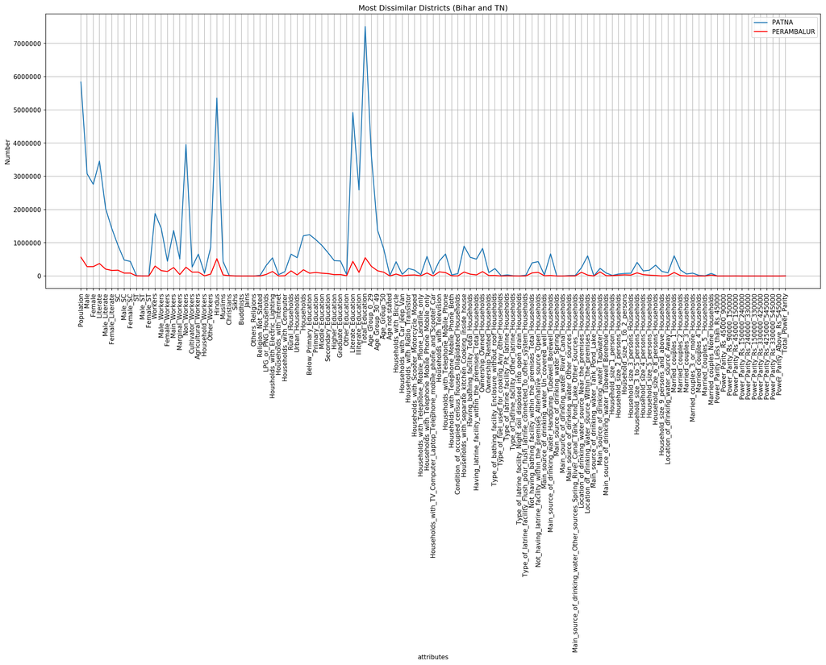

```python
# let us visualise the most dissimilar districts to see whats going on
y1 = Bihar.loc[Bihar['District name']=='Patna']
y1 = y1.values[0][3:]
plt.figure(2,figsize=(22,8), dpi = 150)
plt.plot(x,y1, label='PATNA')
y2 = TN.loc[TN['District name']=='Perambalur']
y2 = y2.values[0][3:]
plt.plot(x,y2, color='red', label='PERAMBALUR')
plt.legend()
plt.ylabel('Number')
plt.xlabel('attributes')
plt.title('Most Dissimilar Districts (Bihar and TN)')
plt.xticks(x,atts, rotation=90)
plt.grid()
plt.legend()
```

As we can see, Patna and perambalur are very dissimilar districts as per the census. It must be because of the population differences.

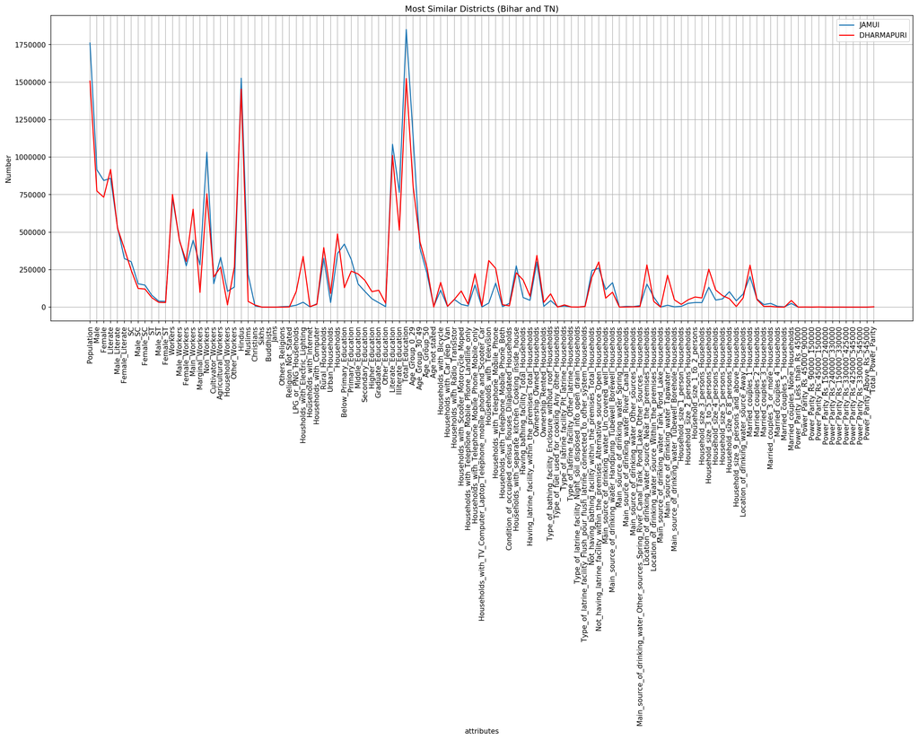

```python
# Now lets visualise the data of jamui and dharmapuri which are most similar as per mean error
y1 = Bihar.loc[Bihar['District name']=='Jamui']
y1 = y1.values[0][3:]
plt.figure(2,figsize=(22,8), dpi = 150)
plt.plot(x,y1,label='JAMUI')
y2 = TN.loc[TN['District name']=='Dharmapuri']
y2 = y2.values[0][3:]
plt.plot(x,y2, color='red', label='DHARMAPURI')
plt.ylabel('Number')
plt.xlabel('attributes')
plt.title('Most Similar Districts (Bihar and TN)')
plt.xticks(x,atts, rotation=90)
plt.grid()
plt.legend()
```

Jamui and Dharmapuri districts look statistically almost the same!

## Variation of Mobile penetration with number of Agricultural workers

Let us again make a new dataframe so that we can analyse properly. We will first see the correlation heatmap and then further analyse the data

```python
dff = pd.concat([df['State name'],df['Agricultural_Workers'],df['Households_with_Telephone_Mobile_Phone']], axis=1)
dff['Mobile Penetration'] = dff['Households_with_Telephone_Mobile_Phone']/df['Population']
dff['Agricultural workers per pop'] = dff['Agricultural_Workers']/df['Population']
dff.head()
```

|  | State name | Agricultural_Workers | Households_with_Telephone_Mobile_Phone | Mobile Penetration | Agricultural workers per pop |
| --- | --- | --- | --- | --- | --- |
| 0 | JAMMU & KASHMIR | 56759 | 56495 | 0.064910 | 0.065214 |
| 1 | JAMMU & KASHMIR | 36630 | 72197 | 0.095784 | 0.048597 |
| 2 | JAMMU & KASHMIR | 1645 | 13836 | 0.103651 | 0.012323 |
| 3 | JAMMU & KASHMIR | 3763 | 10562 | 0.075013 | 0.026725 |
| 4 | JAMMU & KASHMIR | 31583 | 36358 | 0.076249 | 0.066235 |

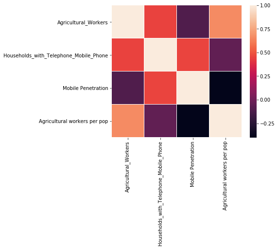

```python
f,ax = plt.subplots(figsize=(6, 5))
sns.heatmap(dff.corr(), linewidths=.2,ax=ax)
```

Now we use the joint plot to analyse the data.

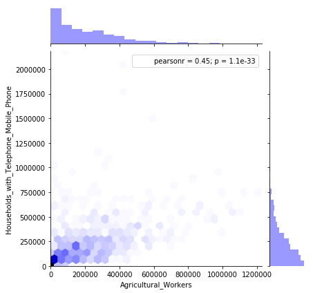

```python
sns.jointplot(x=df['Agricultural_Workers'], y=df['Households_with_Telephone_Mobile_Phone'], kind="hex", color="b", size=6);
```

Lets draw a regression plot to see the relation between the two fields.

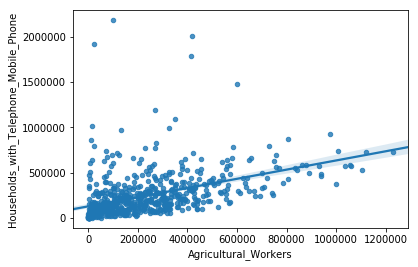

```python
sns.regplot(x='Agricultural_Workers',y='Households_with_Telephone_Mobile_Phone',data=df, scatter_kws={"s": 20})
```

The relation seems somewhat linear but the plot has too many outliers to deduce anything.

Now we will plot the agriculture workers vs mobile penetration (mobile users/population)

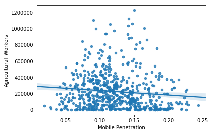

```python
sns.regplot(x='Mobile Penetration',y='Agricultural_Workers',data=dff, scatter_kws={"s": 20})
```

This plot shows no special relation between the two attributes.